# Project check 4

Author

Hailey Ernest and Nicole Yee

# **Project Checkpoint 1**

## **Data Context**

This data describes the number of measles and rubella cases from 194 countries. It documents cases each month and year from January 2012 to July 2025. It is provided by the World Health Organization (WHO). Member states report this information to WHO as part of the WHO UNICEF annual data collection exercise. This data is used for investigation into monthly cases and is of interest for monitoring immunization.

## **Data Cleaning**

The two data sets were cleaned separately. For the month dataset, column names were renamed using the janitor package. The content of each name is the same, it is just renamed in snake case. The data is also read in to ensure that all columns but region, country, and iso3 (country code) are numeric. No variables are created or modified otherwise.

The cases by year dataset is cleaned in a bit more detail. First, the first row becomes the column names. Then, column names are renamed using snake case so that they can easily be renamed to match the month dataset. The columns country, iso3, measles_total, measles_lab_confirmed, measles_epi_linked, measles_clinical, rubella_total, rubella_lab_confirmed, rubella_epi_linked, and rueball_clinical were renamed from member_state, iso_country_code, number_of_measles_cases_by_confirmation_method, na, na_2, na_3, number_of_rubella_cases_by_confirmation_method, na_4, na_5, and na_6 respectively. No other datatypes were changed and no variables were created.

## **Research Questions with Original Data**

1. Are certain countries showing more improvement in containing measles and rubella cases in recent years more than others?
2. Is there a time of year where measles and rubella cases become more common globally?
3. What proportion of suspected measles cases are discarded, and does this vary by region (in a single year)?
4. Do Epidemiologically-linked cases make more of total confirmed cases compared to clinically-compatible cases, and does this differ between measles and rubella?

## **Research Questions with Supplemental Data**

1. Is there a consistently noticeable gap in monthly rubella cases between countries that have introduced the rubella vaccine and countries that have not?
2. How long does it take for measles and rubella cases to noticeably drop after countries introduce vaccinations?
3. Are countries with lower vaccination rates associated with higher measles incidence rates per million population?
4. Do countries with lower GDP or weaker healthcare access have a higher proportion of clinically-compatible cases relative to lab-confirmed cases, meaning possibly limited diagnostic capacity?

## **Data Visualization Sketches**

[figure not shown]

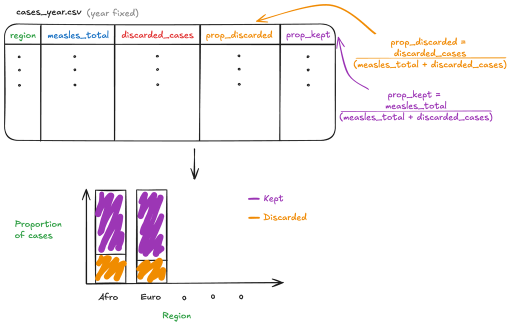

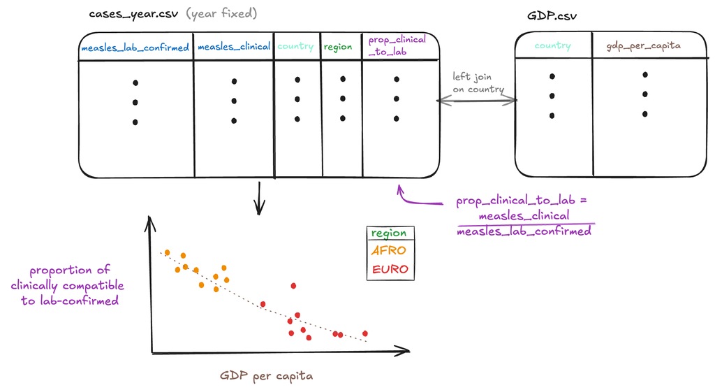

# **Project Checkpoint 2**

### **Months with highest measles case count each year**

*Existing columns summary:*

*Custom function and iteration*

```r
# function to get the month of a year with the highest number of cases
max_month <- function(yr){
  cases_month |>
    filter(year == yr) |>
    group_by(month) |>
    summarize(num_measles = sum(measles_total, na.rm = TRUE)) |>
    slice_max(n=1, order_by = num_measles)
}

cases_year |>
  distinct(year) |>
  # apply function to each year in the data
  mutate(max_month = map(year, max_month)) |>
  # pull out columns from map
  unnest(max_month) |>
  # convert month abbreviations to month names
  mutate(month = month.name[month]) |>
  # make a gt table object
  gt() |>
  # rename and bold each column
  cols_label(
    year = md("**Year**"),
    month = md("**Month**"),
    num_measles = md("**Cases**")
  ) |>
  # add a table title
  tab_header(title = md("Time of Year with Increased Measles Cases Over Time")) |>
  # add a table caption
  tab_caption(caption = md("Months with the Highest Number of Cases.")) |>
  # bold column labels
  tab_style(
    style = cell_text(weight = "bold"),
    locations = cells_column_labels()
  )
```

Months with the Highest Number of Cases.

Time of Year with Increased Measles Cases Over Time

| **Year** | **Month** | **Cases** |
| --- | --- | --- |
| 2012 | January | 15412 |
| 2013 | March | 31287 |
| 2014 | March | 40172 |
| 2015 | April | 38141 |
| 2016 | March | 37368 |
| 2017 | March | 23445 |
| 2018 | November | 32712 |
| 2019 | February | 123126 |
| 2020 | February | 25948 |
| 2021 | April | 6823 |
| 2022 | December | 22938 |
| 2023 | March | 36723 |
| 2024 | March | 61578 |
| 2025 | March | 22485 |

### Proportion of suspected measles cases that are discarded by region (in a single year)

*Existing columns summary:*

*Custom function*

```r
# function to get proportion of suspected cases that are discarded for each region in a given year
prop_discarded_by_region <- function(df, year_input) {
  df |>
    # filter data for selected year
    filter(year == year_input) |>
    # group data by region
    group_by(region) |>
    summarize(
      # total suspected measles cases for each region
      total_suspected = sum(measles_suspect, na.rm = TRUE),
      # total discarded cases for each region
      total_discarded = sum(discarded, na.rm = TRUE),
      # calculate proportion of discarded cases
      prop_discarded = total_discarded / total_suspected,
      .groups = "drop"
    )
}

prop_discarded_by_region(cases_month, 2022) |>
  # make a gt table
  gt() |>
  # format proportion column as percent (easier to understand)
  fmt_percent(columns = prop_discarded, decimals = 2) |>
  # rename columns
  cols_label(
    region = "Region",
    total_suspected = "Total Suspected Cases",
    total_discarded = "Total Discarded Cases",
    prop_discarded = "Proportion Discarded"
  ) |>
  # add a table title and caption
  tab_header(
    title = "Discarded Measles Cases by Region",
    subtitle = "Proportion of Discarded Cases in 2022"
  )|>
  # bold column labels
  tab_style(
    style = cell_text(weight = "bold"),
    locations = cells_column_labels()
  )
```

Discarded Measles Cases by Region

Proportion of Discarded Cases in 2022

| Region | Total Suspected Cases | Total Discarded Cases | Proportion Discarded |
| --- | --- | --- | --- |
| AFR | 116498 | 51576 | 44.27% |
| AMR | 12853 | 12805 | 99.63% |
| EMR | 77939 | 37835 | 48.54% |
| EUR | 6800 | 5922 | 87.09% |
| SEAR | 138731 | 89239 | 64.33% |
| WPR | 37021 | 35630 | 96.24% |

### **Epidemiologically-linked case proportions by region and year**

*Modified columns summary:*

*Custom function and iteration*

```r
# function to get proportion of cases that are epidemiologically-linked for each year in one region
epi_proportions <- function(region) {
  cases_month |>
    filter(region == region) |>
    group_by(year) |>
    # get total counts for each year
    summarise(
      # measles total epidemiologically-linked and lab confirmed
              measles_epi_linked = sum(measles_epi_linked, na.rm = TRUE),
              measles_lab_confirmed = sum(measles_lab_confirmed, na.rm = TRUE),
      # rubella total epidemiologically-linked and lab confirmed
              rubella_epi_linked = sum(rubella_epi_linked, na.rm = TRUE),
              rubella_lab_confirmed = sum(rubella_lab_confirmed, na.rm = TRUE)) |>
    # modify columns by calculating proportions
    mutate(prop_epi_measles = measles_epi_linked / measles_lab_confirmed,
           prop_epi_rubella = rubella_epi_linked / rubella_lab_confirmed) |>
    select(year,
           prop_epi_measles,
           prop_epi_rubella)
}

 cases_year |>
  distinct(region) |>
  # apply function to get proportions for each region
  mutate(epi_props = map(region, epi_proportions)) |>
  # get columns from returned map lists
  unnest(epi_props) |>
  # group by region so the table is divided by region
  group_by(region) |>
  # make a gt table
  gt() |>
   # format the proportion columns to be percents
   fmt_percent(columns = matches("prop"), decimals = 1) |>
   # rename and bold column names
    cols_label(
      region = md("**Region**"),
      year = md("**Year**"),
      prop_epi_measles = md("**Epidemiologically-linked measles cases**"),
      prop_epi_rubella = md("**Epidemiologically-linked rubella cases**")
    ) |>
   # add a table title
   tab_header(
     title = md("Proportion of Confirmed Cases that are Epidemiologically-linked"),
   ) |>
   # add a table caption
   tab_caption(
     caption = md("Changes in each region's confirmed case makeup over time.")
   )
```

Changes in each region’s confirmed case makeup over time.

Proportion of Confirmed Cases that are Epidemiologically-linked

| **Year** | **Epidemiologically-linked measles cases** | **Epidemiologically-linked rubella cases** |
| --- | --- | --- |
| AFRO |  |  |
| 2012 | 56.1% | 44.9% |
| 2013 | 81.7% | 43.4% |
| 2014 | 64.8% | 58.6% |
| 2015 | 71.9% | 31.4% |
| 2016 | 73.9% | 99.8% |
| 2017 | 71.4% | 28.4% |
| 2018 | 64.7% | 16.7% |
| 2019 | 233.5% | 12.5% |
| 2020 | 71.4% | 7.8% |
| 2021 | 26.3% | 4.3% |
| 2022 | 101.8% | 6.7% |
| 2023 | 60.7% | 5.3% |
| 2024 | 51.2% | 1.4% |
| 2025 | 37.0% | 1.1% |
| AMRO |  |  |
| 2012 | 56.1% | 44.9% |
| 2013 | 81.7% | 43.4% |
| 2014 | 64.8% | 58.6% |
| 2015 | 71.9% | 31.4% |
| 2016 | 73.9% | 99.8% |
| 2017 | 71.4% | 28.4% |
| 2018 | 64.7% | 16.7% |
| 2019 | 233.5% | 12.5% |
| 2020 | 71.4% | 7.8% |
| 2021 | 26.3% | 4.3% |
| 2022 | 101.8% | 6.7% |
| 2023 | 60.7% | 5.3% |
| 2024 | 51.2% | 1.4% |
| 2025 | 37.0% | 1.1% |

[output cut: 60 more lines]

### Measles cases for years following vaccine introduction

*Modified columns summary:*

*Iteration*

```r
# get first year with measles vaccine coverage above 0 for each country
measles_intro <- measles_vax |>
  filter(!is.na(coverage), coverage > 0) |>
  group_by(name) |>
  summarize(
    vax_year = min(year),
    .groups = "drop"
  )

# join vaccine introduction year to monthly measles cases
measles_cases_with_vax <- cases_month |>
  select(region, country, year, month, measles_total) |>
  # join vaccine introduction year by country
  left_join(measles_intro, by = c("country" = "name")) |>
  # create modified column for years since vaccine introduction
  mutate(
    years_since_vax = year - vax_year
  )

# use map to get average measles cases by years since vaccine introduction for each country

# Note: when the country’s introduction to vaccine occurred that is what calculated the average on that year, so 1st year is all the countries' averages who were introduced after 1 year (no matter the starting year - one country could have it be in 2012 and another in 2020). And coverage above 0 is the dataset's measure of when there were more than 0 vaccines that year for that country

measles_country_patterns <- measles_cases_with_vax |>
  distinct(country) |>
  filter(!is.na(country)) |>
  mutate(case_pattern = map(country, \(country_input) {
    measles_cases_with_vax |>
      # filter data to one country
      filter(country == country_input,
             !is.na(years_since_vax),
             years_since_vax >= 0) |>
      group_by(years_since_vax) |>
      summarize(
        avg_cases = mean(measles_total, na.rm = TRUE),
        .groups = "drop"
      )
  })) |>
  # columns pulled from mapped results
  unnest(case_pattern)

# summarize across countries for average pattern after vaccine introduction
measles_after_vax <- measles_country_patterns |>
  group_by(years_since_vax) |>
  summarize(
    avg_cases = mean(avg_cases, na.rm = TRUE),
    .groups = "drop"
  )

# make a gt table
measles_after_vax |>
  gt() |>
  # format average cases
  fmt_number(columns = avg_cases, decimals = 1) |>
  # rename columns
  cols_label(
    years_since_vax = "Years Since Vaccine Introduction",
    avg_cases = "Average Measles Cases"
  ) |>
  # add a table title and subtitle
  tab_header(
    title = "Change in Measles Cases After Vaccine Introduction"
  ) |>
  tab_caption(
    caption = "Countries are aligned by the first year (coverage above 0) and averaged across all countries"
  ) |>
  # bold column labels
  tab_style(
    style = cell_text(weight = "bold"),
    locations = cells_column_labels()
  )
```

Countries are aligned by the first year (coverage above 0) and averaged across all countries

Change in Measles Cases After Vaccine Introduction

| Years Since Vaccine Introduction | Average Measles Cases |
| --- | --- |
| 0 | 60.5 |
| 1 | 85.9 |
| 2 | 124.9 |
| 3 | 105.7 |
| 4 | 74.4 |
| 5 | 77.3 |
| 6 | 129.1 |
| 7 | 241.3 |
| 8 | 50.7 |
| 9 | 33.3 |
| 10 | 91.8 |
| 11 | 160.5 |
| 12 | 171.0 |
| 13 | 115.7 |

```r
# use map to get average measles cases by years since vaccine introduction for each region
measles_region_patterns <- measles_cases_with_vax |>
  # get distinct regions from the data
  distinct(region) |>
  # remove missing region values
  filter(!is.na(region)) |>
  # apply function to get case patterns for each region
  mutate(case_pattern = map(region, \(region_input) {
    measles_cases_with_vax |>
      # filter data to one region
      filter(region == region_input,
             !is.na(years_since_vax),
             years_since_vax >= 0) |>
      group_by(years_since_vax) |>
      summarize(
        avg_cases = mean(measles_total, na.rm = TRUE),
        .groups = "drop"
      )
  })) |>
  # get columns from returned map lists
  unnest(case_pattern)

measles_region_patterns |>
  # group by region so the table is divided by region
  group_by(region) |>
  # make a gt table
  gt() |>
  # format average cases
  fmt_number(columns = avg_cases, decimals = 1) |>
  # rename and bold column names
  cols_label(
    region = "Region",
    years_since_vax = "Years Since Vaccine Introduction",
    avg_cases = "Average Measles Cases"
  ) |>
  # add a table title and subtitle
  tab_header(
    title = "Change in Measles Cases After Vaccine Introduction"
  ) |>
  tab_caption(
    caption = "Year 0 represents the first year a country has official coverage
    above 0; values are averaged within each region"
  ) |>
  # bold column labels
  tab_style(
    style = cell_text(weight = "bold"),
    locations = cells_column_labels()
  )
```

Year 0 represents the first year a country has official coverage above 0; values are averaged within each region

Change in Measles Cases After Vaccine Introduction

| Years Since Vaccine Introduction | Average Measles Cases |
| --- | --- |
| AFR |  |
| 0 | 58.2 |
| 1 | 175.6 |
| 2 | 95.2 |
| 3 | 98.9 |
| 4 | 77.7 |
| 5 | 50.9 |
| 6 | 91.3 |
| 7 | 604.9 |
| 8 | 104.4 |
| 9 | 58.9 |
| 10 | 139.6 |
| 11 | 152.3 |
| 12 | 181.7 |
| 13 | 103.5 |
| AMR |  |
| 2 | 29.9 |
| 3 | 1.4 |
| 4 | 0.3 |
| 5 | 3.0 |
| 6 | 58.3 |
| 7 | 74.6 |
| 8 | 39.4 |
| 9 | 3.3 |
| 10 | 0.7 |
| 11 | 0.3 |
| 12 | 1.4 |
| 13 | 42.0 |
| EMR |  |
| 0 | 99.0 |

[output cut: 58 more lines]

## Project Checkpoint 3

### Acquire new country-level data source using webscraping: GDP per capita

```r
# function to scrape one year of gdp data
scrape_gdp_year <- function(year) {

  # create url for a specific year
  url <- paste0(
    "https://ourworldindata.org/grapher/gdp-per-capita-worldbank",
    "?tab=table&time=", year, "..", year,
    "&tableFilter=countries"
  )

  # open browser session: page is dynamic (live)
  b <- ChromoteSession$new()

  # browser closes after function
  on.exit(try(b$close(), silent = TRUE), add = TRUE)

  # go to page
  b$Page$navigate(url)

  # wait for loaded table
  Sys.sleep(5)

  # get rendered html from the page
  eval_result <- b$Runtime$evaluate("document.documentElement.outerHTML")
  rendered_html <- eval_result$result$value

  # read html into r
  page <- read_html(rendered_html)

  # extract the table from the page
  tab <- page |>
    html_element("table") |>
    html_table()

  # keep only country and gdp
  tab_clean <- tab[, 1:2]
  names(tab_clean) <- c("country", "gdp_per_capita")

  # clean the data
  tab_clean <- tab_clean |>
    mutate(
      scraped_year = year, # year
      gdp_per_capita = str_remove_all(gdp_per_capita, "\\$|,"), # remove $ and ,
      gdp_per_capita = na_if(gdp_per_capita, ""), # empty is NA
      gdp_per_capita = as.numeric(gdp_per_capita) # convert to numeric
    ) |>
    filter(country != "Country or region") |>
    filter(!is.na(country))
  tab_clean
}

# create vector of years to scrape
years <- 2012:2024

# loop over all years, then combine
gdp_web <- map_dfr(years, scrape_gdp_year)
head(gdp_web)
```

```
# A tibble: 6 × 3
  country        gdp_per_capita scraped_year
  <chr>                   <dbl>        <int>
1 Afghanistan              2985         2012
2 Aland Islands              NA         2012
3 Albania                 12464         2012
4 Algeria                 14698         2012
5 American Samoa             NA         2012
6 Andorra                 58172         2012
```

### Acquire new country-level data source using API (Checking webscraping result): GDP per capita

```r
# url for owid gdp data
gdp_url <- "https://ourworldindata.org/grapher/gdp-per-capita-worldbank.csv?v=1&csvType=full&useColumnShortNames=false"

# send request to API
response <- GET(gdp_url)

# check status
#status_code(response)

# extract content
gdp_raw <- content(response, as = "text", encoding = "UTF-8")

# read the csv text into a DF
gdp_api <- read_csv(gdp_raw,
                    show_col_types = FALSE) |>
  # keep years 2012 to 2024
  filter(Year >= 2012, Year <= 2024)

head(gdp_api)
```

```
# A tibble: 6 × 5
  Entity      Code   Year `GDP per capita` `World region according to OWID`
  <chr>       <chr> <dbl>            <dbl> <chr>
1 Afghanistan AFG    2012            2985. Asia
2 Afghanistan AFG    2013            3047. Asia
3 Afghanistan AFG    2014            3018. Asia
4 Afghanistan AFG    2015            2968. Asia
5 Afghanistan AFG    2016            2959. Asia
6 Afghanistan AFG    2017            2953. Asia
```

#### Data Context: GDP per capita

This dataset contains country-level GDP per capita data, where the observations are countries and regions around the world. The data includes over 200 countries’ GDP, and ranges from 1990 to 2024, and our Measles project focuses on the years 2012 through 2024. GDP per capita is calculated by dividing a country’s total output by its population and adjusting values with the same international dollars to take into account inflation and living cost differences. The goal of this data is to compare economic performance, living conditions, and economic growth across almost all countries over many years. The data is created by organizations such as the World Bank, IMF, OECD, and Eurostat, and is summarized by Our World in Data. GDP data is collected by national statistical agencies using censuses, surveys, and tax or government data, and then analyzed and organized by the World Bank, IMF, etc.

### Acquire new country-level data source using API: Population density

We are using the API Ninjas API for country populations. To use this API, we had to create an account and request and API key. In the code below we used a placeholder for our API key.

```r
cases_year <- cases_year |>
  # recode country names that are not recognized by the API
  mutate(country_api = recode_values(
    country,
    "Côte d'Ivoire" ~ "Cote d'Ivoire",
    "Bolivia (Plurinational State of)" ~ "Bolivia",
    "Venezuela (Bolivarian Republic of)" ~ "Venezuela",
    "Iran (Islamic Republic of)" ~ "Iran",
    "Netherlands (Kingdom of the)" ~ "Netherlands",
    "Micronesia (Federated States of)" ~ "Micronesia",
    default = country
  ),
  # add %20 in place of spaces so the url in a request works
    country_url = str_replace_all(country_api, " ", "%20"))

# function to get population density per square kilometer each year for a country
get_population_density <- function(country) {

  # check that the country input is a string
  if (!is.character(country)) {
    print("Please enter a country name (string value)!")
    stop()
  }

  # create url string with given country
  url <- glue::glue("https://api.api-ninjas.com/v1/population?country={country}")

  # request from the API
  densities <- GET(url,
    # API key is in a hidden code chunk
    add_headers("X-Api-Key"={key})) %>%
    # pull and process output
    .$content %>%
    rawToChar() |>
    # enter population statistics (contains density!)
    enter_object(historical_population) |>
    gather_array() |>
    # cannot use spread_all because some countries have NA for columns
    spread_values(
      # jnumber makes it numeric, otherwise it throws an error
      year = jnumber(year),
      density = jnumber(density))

  # check if no output (API does not have data for a country)
  if (NROW(densities) == 0) {
    NULL
  } else {
    # otherwise return a df of the densities, year, and country name
    densities |>
      select(year, density) |>
      mutate(country = str_replace_all(country, "%20", " "))
  }
}

# iterate over all countries and get densities
results <- map_dfr(.x = unique(cases_year$country_url),
                   .f = get_population_density) |>
  select(year, density, country) |>
  # make a tibble to join later (threw an error without this)
  as_tibble()

head(results)
```

```
# A tibble: 6 × 3
   year density country
  <dbl>   <dbl> <chr>
1  2024      20 Algeria
2  2023      19 Algeria
3  2022      19 Algeria
4  2020      18 Algeria
5  2015      17 Algeria
6  2010      15 Algeria
```

#### Data Context: Population density

This dataset contains country-level population density data. It includes population density per square kilometer for countries over the years. Country population density describes the number of people per square kilometer. It is calculated by dividing the total population of a country by it’s total land area. Population counts are usually collected by censuses and surveys, and population density is derived from that data. Population density is a measure of how crowded a country is. We wanted to use population density data to investigate if there is a notable relationship between density and measles case counts, since measles is highly contagious and can be airborne. This data was compiled from API Ninjas’ Population API. API Ninja does not disclose where they compile their data from.

### Data Joining

```r
# clean gdp data so country and year match the cases data
gdp_web_clean <- gdp_web |>
  rename(
    country = country,
    year = scraped_year
  )
# join gdp data to the yearly cases data
cases_year_gdp <- cases_year |>
  left_join(gdp_web_clean,
            by = c("country", "year"))
# join the yearly gdp/cases data to the monthly cases data
cases_gdp <- cases_month |>
  left_join(
    cases_year_gdp,
    by = c("country", "year"),
    suffix = c("_month", "_year")
  ) |>
  # make a tibble to join (threw an error without this)
  as_tibble() |>
  # join densities with data by country and year
  left_join(results, by = join_by(country == country,
                                  year == year)) |>
  # drop country columns formatted for the API request
  select(!c(country_url, country_api))
```

### Data Visualizations

#### GDP per capita

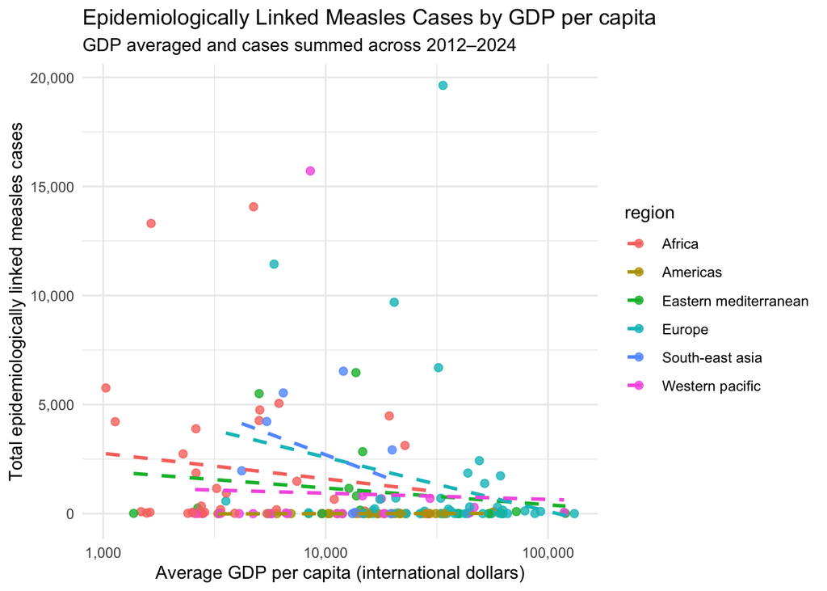

```r
# create dataset: epi-linked cases and join average gdp across all years
cases_gdp_country <- cases_year |>

  # remove 2025 for plotting (no gdp data)
  filter(year != 2025) |>

  # group by country and region
  group_by(country, region) |>

  # sum epidemiologically linked cases
  summarise(
    epi_linked = sum(measles_epi_linked, na.rm = TRUE),
    .groups = "drop"
  ) |>

  # join average gdp per country
  left_join(
    gdp_web |>
      group_by(country) |>
      summarise(
        avg_gdp_per_capita = mean(gdp_per_capita, na.rm = TRUE),
        .groups = "drop"
      ),
    by = "country"
  ) |>

  # rename regions to full names
  mutate(
    region = recode(region,
      "AFRO" = "Africa",
      "AMRO" = "Americas",
      "EMRO" = "Eastern mediterranean",
      "EURO" = "Europe",
      "SEARO" = "South-east asia",
      "WPRO" = "Western pacific"
    )
  ) |>

  # remove missing values and limit cases
  filter(
    !is.na(avg_gdp_per_capita),
    !is.na(epi_linked),
    epi_linked <= 20000
  )

# create plot
ggplot(cases_gdp_country,
       aes(x = avg_gdp_per_capita,
           y = epi_linked,
           color = region)) +
  geom_point(alpha = 0.8, size = 2) +
  # add trend line
  geom_smooth(method = "lm", formula = y ~ x, se = FALSE, linetype = "dashed") +
  # no scientific notation for GDP
  scale_x_log10(labels = scales::comma) +
  # show full numbers on y axis
  scale_y_continuous(labels = scales::comma) +
  # labels
  labs(
    title = "Epidemiologically Linked Measles Cases by GDP per capita",
    subtitle = "GDP averaged and cases summed across 2012–2024",
    x = "Average GDP per capita (international dollars)",
    y = "Total epidemiologically linked measles cases",
    color = "region"
  ) +
  theme_minimal()
```

This scatterplot shows the relationship between average GDP per capita and total epidemiologically linked measles cases for all countries. Each point represents one country, with average GDP and totaled case numbers from years 2012 to 2024. Countries with higher GDP per capita tend to be associated with less epidemiologically linked measles cases. Regional differences are also shown, as some countries in lower income/economy regions tend to have higher case counts.

#### Population Density

```r
quantile(cases_gdp$density, na.rm = TRUE)
```

```
   0%   25%   50%   75%  100%
    2    31    81   162 25927
```

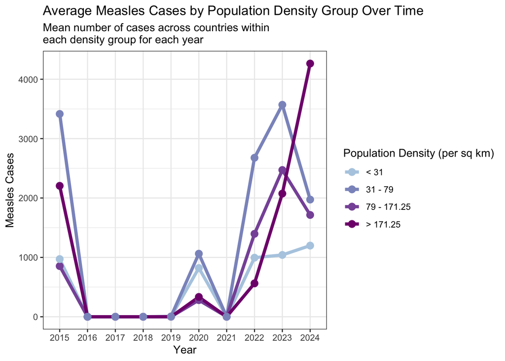

```r
cases_gdp |>
  # create density bins based on quantiles of country densities
  mutate(binned_density = case_when(
    is.na(density) ~ "NA",
    density < 31 ~ "< 31",
    density >= 31 & density < 79 ~ "31 - 79",
    density >= 79 & density < 171.25~ "79 - 171.25",
    density >= 171.25 ~ "> 171.25"
  )) |>
  filter(binned_density != "NA") |>
  # take averages of cases across countries for each year, within density bins
  group_by(year, binned_density) |>
  summarise(measles_mean = mean(measles_total_year, na.rm = TRUE),
            rubella_mean = mean(rubella_total_year), na.rm = TRUE) |>
  # plot - make year a factor to show all years on the xaxis
  ggplot(aes(x=factor(year),
             y=measles_mean,
             color = binned_density,
             group = binned_density)) +
  # line plot
  geom_path(size = 1.5) +
  # overlay points to clarify obervations by year
  geom_point(size = 3) +
  # customize colors and legend
  scale_color_manual(name = "Population Density (per sq km)",
                     values = c("#b3cde3", "#8c96c6", "#8856a7", "#810f7c"),
                     labels = c("< 31", "31 - 79", "79 - 171.25", "> 171.25")) +
  theme_bw() +
  labs(x="Year",
       y="Measles Cases",
       title = "Average Measles Cases by Population Density Group Over Time",
       subtitle = "Mean number of cases across countries within \neach density group for each year")
```

The visualization above shows the relationship between average number of measles cases with population density. The number of cases is averaged across countries in each population density group. Measles is a contagious airborne disease, so we wanted to investigate if there was a general relationship between number of cases and country population density. It does not appear that there is a stable relationship, since higher density countries do not have a consistently higher number of cases. This visualization suggests that population density alone is not a strong indicator of number of measles cases and other factors should be looked in to.

## Project Checkpoint 4

### Visualization 1: Trends in Measles and Rubella Cases

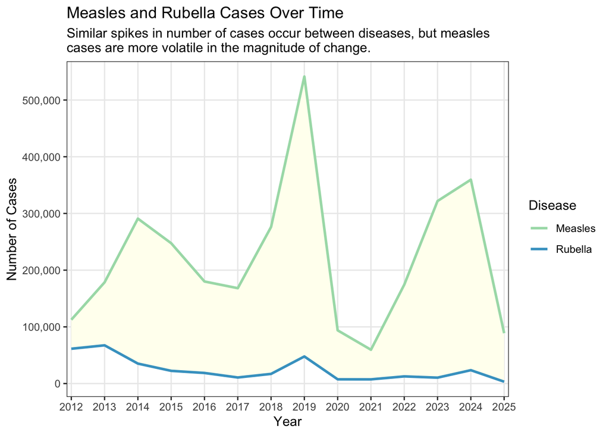

```r
cases_year |>
  group_by(year) |>
  summarize(measles = sum(measles_total, na.rm = TRUE),
            rubella = sum(rubella_total, na.rm = TRUE)) |>
  ggplot() +
  geom_ribbon(aes(x = year, ymin = measles, ymax = rubella),
              position = "identity",
              inherit.aes = FALSE,
              fill = "ivory1") +
  geom_line(aes(x = year,
                y = measles,
                color = "Measles"),
            linewidth = 1) +
  geom_line(aes(x = year,
                y = rubella,
            color = "Rubella"),
            linewidth = 1) +
  scale_color_manual(name = "Disease",
                     values = c("Measles" = "#a8ddb5", "Rubella" = "#43a2ca")) +
  scale_x_continuous(breaks = unique(cases_year$year),
                     expand = c(0.01,0.01)) +
  scale_y_continuous(breaks = seq(0, 600000, by = 100000),
                     labels = scales::label_comma()) +
  theme_bw() +
  labs(x = "Year",
       y = "Number of Cases",
       title = "Measles and Rubella Cases Over Time",
       subtitle = "Similar spikes in number of cases occur between diseases, but measles \ncases are more volatile in the magnitude of change.") +
  theme(panel.grid.minor = element_blank())
```

### Visualization 2: Measles Cases by Month

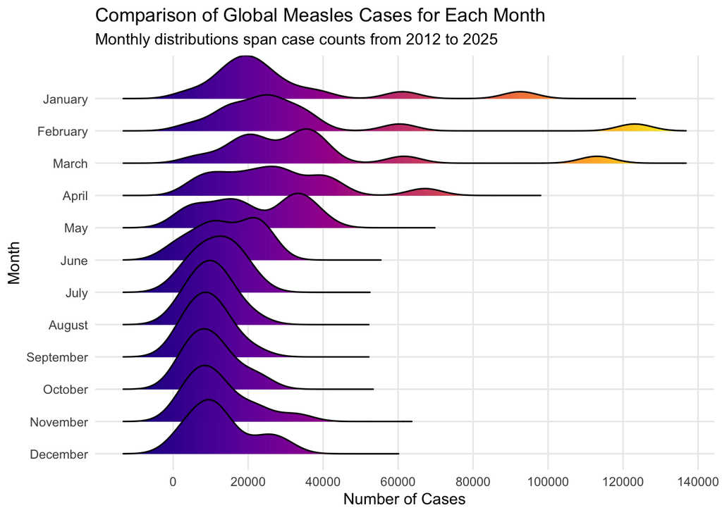

```r
cases_month |>
  group_by(month, year) |>
  summarise(measles_total = sum(measles_total, na.rm = TRUE)) |>
  mutate(month_full = month.name[month]) |>
  ggplot(aes(x = measles_total,
             y = reorder(month_full, -month),
             group = month,
             fill = ..x..)) +
  geom_density_ridges_gradient(scale = 2, rel_min_height = 0.00000000001,
                               alpha = 0.5) +
  scale_fill_viridis(name = "Number of Cases", option = "C") +
  scale_x_continuous(breaks = seq(0, 140000, by = 20000)) +
  scale_y_discrete(expand = c(0.0001,0.5)) +
  theme_minimal() +
  labs(x = "Number of Cases",
       y = "Month",
       title = "Comparison of Global Measles Cases for Each Month",
       subtitle = "Monthly distributions span case counts from 2012 to 2025") +
  theme(panel.grid.minor.x = element_blank(),
        legend.position = "none")
```

### Statistical Model:

#### Research Question

Are countries with lower GDP per capita associated with higher numbers of epidemiologically linked measles cases?

This model evaluates the relationship between GDP per capita and epidemiologically linked measles cases. GDP per capita is used as a measure of a country’s economic development, and epidemiologically linked cases show patterns of disease transmittion based on geography. The model uses country-year observations from 2012 to 2024. The variables are both log-transformed to account for skewness across countries, since changes at lower income levels might have a larger impact than at higher income levels. This is consistent with used approaches in recent global health research.

```r
# create model dataset
epi_gdp_model_data <- cases_gdp |>
  distinct(country, year, region_year, gdp_per_capita, measles_epi_linked_year) |>
  filter(
    year != 2025,
    gdp_per_capita > 0
  ) |>
  drop_na(gdp_per_capita, measles_epi_linked_year) |>
  mutate(
    log_gdp = log10(gdp_per_capita),
    log_epi_linked = log1p(measles_epi_linked_year)
  )

# fit model
epi_gdp_model <- lm(
  log_epi_linked ~ log_gdp,
  data = epi_gdp_model_data
)

# make coefficient table from model summary
coef_table <- as.data.frame(summary(epi_gdp_model)$coefficients) |>
  rownames_to_column(var = "term")

coef_table |>
  gt() |>
  # format values
  fmt_number(
    columns = c(Estimate, `Std. Error`, `t value`, `Pr(>|t|)`),
    decimals = 3
  ) |>
  sub_small_vals(
    columns = `Pr(>|t|)`,
    threshold = 0.001
  ) |>
  cols_align(align = "center") |>
  # rename column headers
  cols_label(
    term = "Model Term",
    Estimate = "Estimate",
    `Std. Error` = "Standard Error",
    `t value` = "t Statistic",
    `Pr(>|t|)` = "p-value"
  ) |>
  # add title and subtitle
  tab_header(
    title = "Model Results: GDP and Epidemiologically Linked Measles Cases",
    subtitle = "Log-log linear regression model"
  ) |>
  # add caption
  tab_caption(
    caption = "Table summarizing the relationship between GDP per capita and epidemiologically linked measles cases."
  ) |>
  # bold column labels
  tab_style(
    style = cell_text(weight = "bold"),
    locations = cells_column_labels()
  )
```

Table summarizing the relationship between GDP per capita and epidemiologically linked measles cases.

Model Results: GDP and Epidemiologically Linked Measles Cases

Log-log linear regression model

| Model Term | Estimate | Standard Error | t Statistic | p-value |
| --- | --- | --- | --- | --- |
| (Intercept) | 4.361 | 0.446 | 9.784 | <0.001 |
| log_gdp | −0.743 | 0.107 | −6.918 | <0.001 |

The coefficient for log GDP per capita is negative and statistically significant, meaning that higher log GDP per capita is associated with lower numbers of epidemiologically linked measles cases.